# The Repression Events Data (RED) Project

December 2022

## Repression and Human Rights

What goes into the decision to repress citizens? Repression is purposeful - leaders choose repressive agents, targets, and repressive methods.

- Research on human rights mostly focuses on human rights outcomes (what leads to more/less violations).
- The repression literature has focused on leaders’ incentives, and behavioral choices about whether, when, and how to repress. Repression here includes risks due to agency loss or the potential to escalate beyond what a leader hoped.

## Repression measures

While good measures of human rights outcomes exist, measures of repressive efforts are few. This project aims to measure

- events where authorities use force or the threat of force against civilians.
- what repressive agents take action against civilians.
- what actions those agents take.
- who the repressive action targets.

If we want to test theories examining the repression-dissent nexus we also need geocoded data with specific event dates and locations.

## Why do we want these data?

- to measure behavior in granular detail, permitting tests of more fine-grained claims about repression, and inferences about the human rights outcomes that follow.
- to speak to “repressive repertoires” or the “normal” repressive approches states take. Do states have preferred repressive targets, tools, and tactics?
- to understand how states use threats of repression or implied punishment (say through banning activities) to mute dissent.
- event data on repression will permit comparison to protest event data (e.g., Mass Mobilization data) to further how we understand the relationships between dissent and repression.

## Repressive Repertoires

Do states, or certain types of governments, or certain leaders tend toward particular levels of repression, to particular repressive tools, agents, and targets?

- What do those patterns tell us to expect about repression and human rights?
- What do deviations from those patterns imply?
- Different groups will be met with different repressive responses (i.e ethnic minorities versus regime supporters).

## What if Repressive Repertoires Fail

If standard repertoires do not work, then leaders may improvise:

- Escalate/De-escalate repression intensity
- Accommodate demands
- Bring in new repressive agents
- Alter repressive tactics

Cirumstances like these are potentially dangerous to civilians and to stability.

## Repression Event Data (RED)

Consistent with definitions of repression (e.g. Conrad & Ritter’s), repression events can be realized OR threatened, overt OR covert, violent OR non-violent.

## RED project plan

Phase 1 (complete) - Human Coded Event data ~1,800 in 116 countries between 1999-2014.

Phase 2 (ongoing)- Machine assisted mass coding of news articles via Lexis Nexis and/or ProQuest. The goal is to code the 1990-2022 period for the international system.

## Repression Events, 1999-2014

[interactive chart not shown]

## Repression Targets

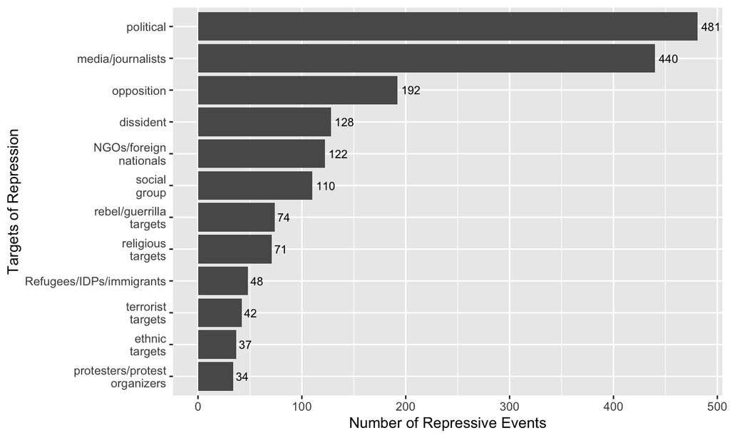

## Repressive Act

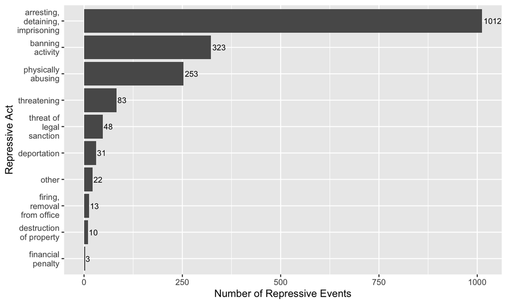

## Repressing Authorities

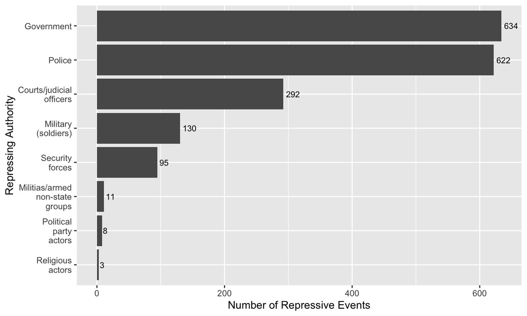

## Repression Events by Liberalism (VDEM)

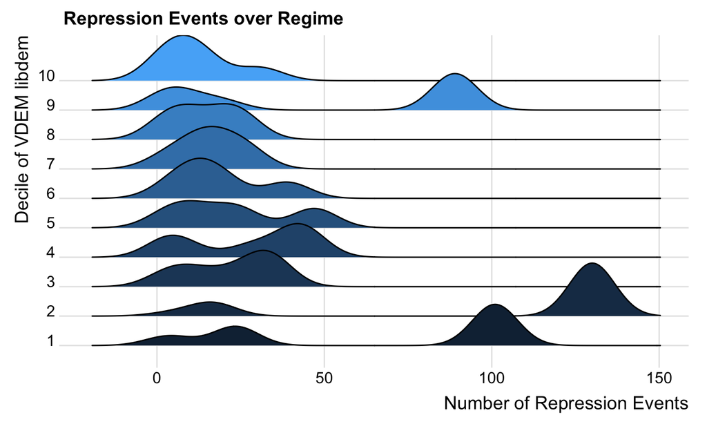

## Repression Events by Polity

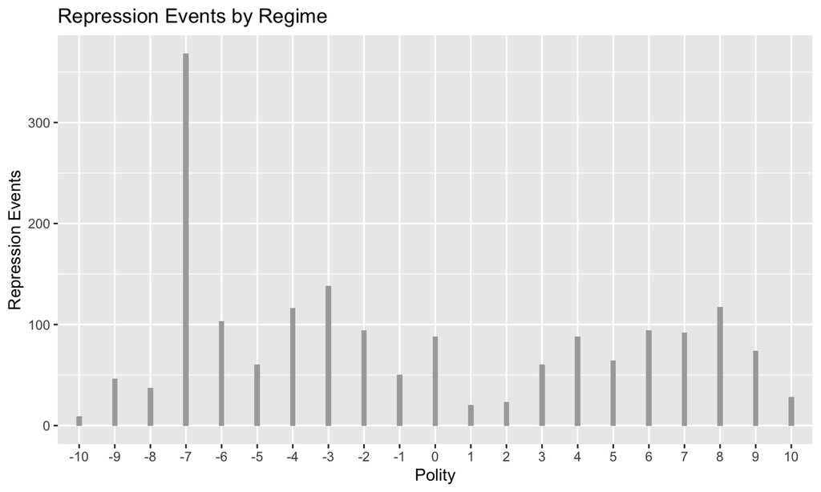

## Other measurement projects

- CIRIGHTS, PTS, V-Dem, HRMI - country-year scores for repression in countries can be the same even when the agents, tactics, and targets of that repression are completely different. No sub-national location data.
- SNARP - event data coded out of human rights reports. Unable to disaggregate descriptions such as “widespread violations” into underlying events which are more likely to be captured in news reporting. Does not include threats or institutional repression.

## Phase 2: Machine Coding

Motivation:

- Manual coding of repression events is labor intensive and time consuming;
- Advances in natural language processing and access to industrial-strength free open-source libraries such as SpaCy allows automating parts of the events data coding process.
- Existing machine-coded events datasets while being immensely helpful lack transparency, often do not code key features.

## Phase 2: Machine Coding Approach

- It’s probably neither possible nor desirable to replace human-coders all together. We adopt a “centaur” approach combining machine and human coding elements.
- “Cold” searches for events produces two types of returns - true positives (actual events), and false positives.
- Our approach is to use existing event data collections (e.g., ICEWS, Phoenix) sets of actual events as the universe, then to use rule-based matching to detect those repression related events, and extract relevant information (e.g. actors, the nature of repressive event etc.).

We are in the process of piloting this approach and are working with source providers (LN, ProQuest).

## Discussion

The RED data capture details of repressive behavior that will permit inferences, and we hope, forecasts about:

- leaders’ choices about repression targets, timing, and escalation.
- how threats and implied violence shape civilian behavior and shape protests.
- patterns in repression repertoires, and deviations from those repertoires.
- the intersection of repressive choices and protester choices.
- human rights outcomes.

## Thank you

We’re grateful for comments and questions.

Contact at:

Dave Clark

dclark@binghamton.edu

## Targets of repression

[interactive chart not shown]

## Repressive Acts

[interactive chart not shown]